Visas kodas yra randamas: https://github.com/geedit/lg-uzduotis

Arba šio puslapio gale.

## Kaip veikia:

- Iš turimų duomenų sukuriamos 13 mėnesių sekos. Tai reiškia, kad algoritmas gaus 13 mėnesių praeities duomenų nuspėti 14-tą mėnesį (kode randama funkcija sequences_generator). Vizualus pavyzdys:

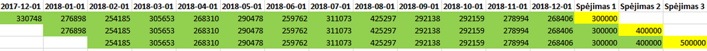

- Šios skaičių sekos naudojamos XGBoost algoritmo išmokymui, naudojant duomenis nuo 2009-01 iki 2017-12, bei testuoti tikslumą, nuo 2018-01 iki 2018-12. Testavimui buvo pasirinktas vidutinis absoliutus nuokrypis (mean absolute error).
- Skaičių prognozavimas į ateitį veikia pasirinkus paskutinius 13 mėnesių duomenų, prognozuoti 14-tą mėnesį. Išprognozuotas skaičius yra pridedamas į 13 mėnesių skaičių sekos galą ir visas procesas yra kartojamas kol yra išprognozuoti visi 12-lika 2019 metų mėnesių.
- Pridėta funkcija išsaugoti 2019-tų metų prognozę į atskirą excel file'ą.

## Kas nebuvo padaryta:

- Tiksliausio modelio pasirinkimas/optimizavimas, papildomų duomenų pridėjimas/sukūrimas.
- Modelio sukūrimas, kuris paimtų visas 5 laiko eilutes ir prognozuotų 5 skaičius vienu metu, sukuriant tarpusavio įtaką visiems duomenims.
- Išbandyta procentiniai, arba logoritminiai, pokyčiai, kurie reikalauja daug laiko modelio optimizavimui, bet dažnai duoda tikslesnius rezultatus.
- K-fold, cross-validation ir kita

```python
from main import *
```

## Total-Augalines kilmes produktai.xlsx

```
Using - data\Total-Augalines kilmes produktai.xlsx
```

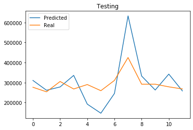

```
Test data range from 2018-01-01 to 2018-12-01
Testing using 11.0 % of total dataset
Mean absolute error - 63591.72265625
Average real price during this period - 293612.75
#####
```

```python
file = 'data\\Total-Augalines kilmes produktai.xlsx'
modelis = Predict_model()
modelis.train_predict_one(file)
```

```
2019-01-01 predicted - 232195.0
2019-02-01 predicted - 230908.0
2019-03-01 predicted - 282216.0
2019-04-01 predicted - 256930.0
2019-05-01 predicted - 275838.0
2019-06-01 predicted - 242241.0
2019-07-01 predicted - 316987.0
2019-08-01 predicted - 401377.0
2019-09-01 predicted - 284111.0
2019-10-01 predicted - 295393.0
2019-11-01 predicted - 277861.0
2019-12-01 predicted - 271123.0
```

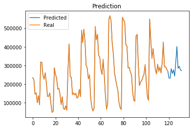

```
#####
```

```python
modelis.future_predict()
```

```python
modelis.save_future_prediction()
```

```
Using - data\Total-Augalines kilmes produktai.xlsx
Enter file name: aaa
File aaa.xlsx was saved in data folder
#####
```

## Total-Kietasis mineralinis kuras.xlsx

```
Using - data\Total-Kietasis mineralinis kuras.xlsx
```

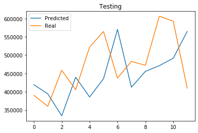

```
Test data range from 2018-01-01 to 2018-12-01
Testing using 11.0 % of total dataset
Mean absolute error - 91421.88802083333
Average real price during this period - 475263.5833333333
#####
```

```python
file = 'data\\Total-Kietasis mineralinis kuras.xlsx'
modelis = Predict_model()
modelis.train_predict_one(file)
```

```
2019-01-01 predicted - 379566.0
2019-02-01 predicted - 397678.0
2019-03-01 predicted - 420549.0
2019-04-01 predicted - 335817.0
2019-05-01 predicted - 367746.0
2019-06-01 predicted - 344667.0
2019-07-01 predicted - 343158.0
2019-08-01 predicted - 354937.0
2019-09-01 predicted - 355084.0
2019-10-01 predicted - 377779.0
2019-11-01 predicted - 341324.0
2019-12-01 predicted - 314057.0
```

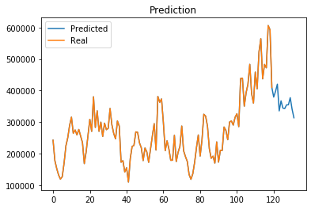

```
#####
```

```python
modelis.future_predict()
```

## Total-Maisto pramones produktai.xlsx

```
Using - data\Total-Maisto pramones produktai.xlsx
```

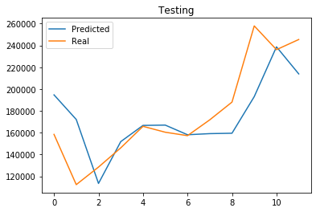

```
Test data range from 2018-01-01 to 2018-12-01
Testing using 11.0 % of total dataset
Mean absolute error - 22093.473958333332
Average real price during this period - 177391.33333333334
#####
```

```python
file = 'data\\Total-Maisto pramones produktai.xlsx'
modelis = Predict_model()
modelis.train_predict_one(file)
```

```
2019-01-01 predicted - 181895.0
2019-02-01 predicted - 157724.0
2019-03-01 predicted - 157975.0
2019-04-01 predicted - 169390.0
2019-05-01 predicted - 175719.0
2019-06-01 predicted - 173106.0
2019-07-01 predicted - 151384.0
2019-08-01 predicted - 162155.0
2019-09-01 predicted - 162931.0
2019-10-01 predicted - 193167.0
2019-11-01 predicted - 190204.0
2019-12-01 predicted - 185596.0
```

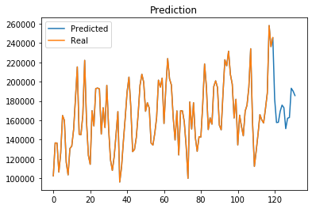

```
#####
```

```python
modelis.future_predict()
```

## Total-Mediena, kametiena.xlsx

```
Using - data\Total-Mediena, kametiena.xlsx
```

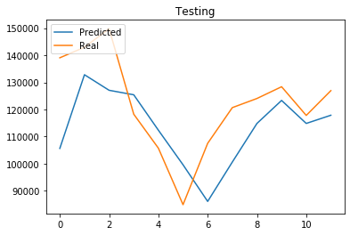

```
Test data range from 2018-01-01 to 2018-12-01
Testing using 11.0 % of total dataset
Mean absolute error - 13533.923177083334
Average real price during this period - 122180.25
#####
```

```python
file = 'data\\Total-Mediena, kametiena.xlsx'
modelis = Predict_model()
modelis.train_predict_one(file)
```

```
2019-01-01 predicted - 125442.0
2019-02-01 predicted - 120179.0
2019-03-01 predicted - 116204.0
2019-04-01 predicted - 92665.0
2019-05-01 predicted - 83139.0
2019-06-01 predicted - 74167.0
2019-07-01 predicted - 85593.0
2019-08-01 predicted - 92436.0
2019-09-01 predicted - 93151.0
2019-10-01 predicted - 93888.0
2019-11-01 predicted - 89152.0
2019-12-01 predicted - 93667.0
```

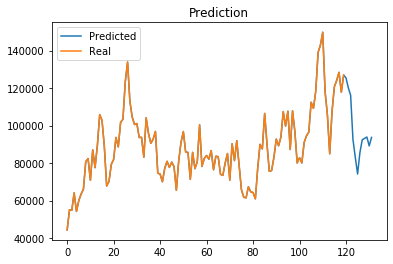

```
#####
```

```python
modelis.future_predict()
```

## Total-Nafta ir naftos produktai.xlsx

```
Using - data\Total-Nafta ir naftos produktai.xlsx
```

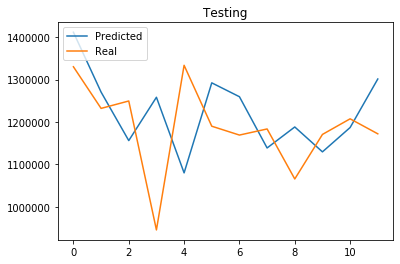

```
Test data range from 2018-01-01 to 2018-12-01
Testing using 11.0 % of total dataset
Mean absolute error - 110870.82291666667
Average real price during this period - 1187397.8333333333
#####
```

```python
file = 'data\\Total-Nafta ir naftos produktai.xlsx'
modelis = Predict_model()
modelis.train_predict_one(file)
```

```
2019-01-01 predicted - 1174053.0
2019-02-01 predicted - 1162283.0
2019-03-01 predicted - 1183212.0
2019-04-01 predicted - 1145311.0
2019-05-01 predicted - 1233607.0
2019-06-01 predicted - 1213589.0
2019-07-01 predicted - 1213240.0
2019-08-01 predicted - 1203556.0
2019-09-01 predicted - 1187668.0
2019-10-01 predicted - 1218734.0
2019-11-01 predicted - 1222552.0
2019-12-01 predicted - 1225640.0
```

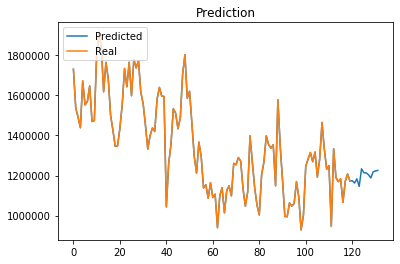

```
#####
```

```python
modelis.future_predict()
```

## Pilnas kodas:

```python
import pandas as pd
import numpy as np
from sklearn import preprocessing
import xgboost as xgb
from sklearn.model_selection import train_test_split
import matplotlib.pyplot as plt
from sklearn.metrics import mean_absolute_error
from datetime import date
from dateutil.relativedelta import relativedelta
from sklearn.multioutput import MultiOutputRegressor


##### helper functions

def data_load(file):
    if file.endswith(".xlsx"):
        data = pd.read_excel(file)
        data['Date'] = pd.to_datetime(data['Date'], format="%Y-%m-%d")
        data = data.drop('Unnamed: 0', axis=1)
        data.dropna(inplace = True)
        return data
    else:
        raise Exception("Bad file format. Try using .xlsx")

def sequences_generator(sequence, seq_len = 13, step=1):
    sequences = []
    next_sequences = []
    for i in range(0, len(sequence) - seq_len, step):
        sequences.append(sequence[i: i + seq_len])
        next_sequences.append(sequence[i + seq_len])
    return np.array(sequences), np.array(next_sequences)

def sequences_generator_future(sequence, seq_len = 13, step=1):
    sequences = []
    for i in range(0, len(sequence) - seq_len, step):
        sequences.append(sequence[i+1: i + seq_len+1])
    return np.array(sequences)

####

class Predict_model():

    def __init__(self):
        self.model = xgb.XGBRegressor(n_estimators=1000, seed=1234, booster = 'gblinear')

    def train_predict_one(self, file):

       # if file == 'data\Total-All.xlsx':
       #     self.columns = ['Augalines kilmes produktai', 'Kietasis mineralinis kuras',
       #                    'Maisto pramones produktai', 'Mediena, kametiena',
       #                    'Nafta ir naftos produktai']
       #     self.model = MultiOutputRegressor(self.model)
       # else:

        self.columns = 'Total'
        self.file = file
        self.data = data_load(file)
        print(f'Using - {self.file}')

        x, y = sequences_generator(self.data[self.columns].values)

        self.split_size = 0.11
        self.x_train, self.x_test, self.y_train, self.y_test = train_test_split(x, y,
                                                                                test_size = self.split_size,
                                                                                shuffle=False,
                                                                                random_state=1234)


        self.model.fit(self.x_train,self.y_train)

        model_results = self.model.predict(self.x_test)

        plt.plot(model_results, label="Predicted")
        plt.plot(self.y_test, label="Real")
        plt.title('Testing')
        plt.legend(loc="upper left")
        plt.show()

        self.starting_date = (self.data.Date.iloc[ - len(self.y_test)]).date()
        self.end_date = (self.data.Date.iloc[ - 1]).date()

        print(f'Test data range from {self.starting_date} to {self.end_date}')
        print(f'Testing using {self.split_size*100} % of total dataset')
        print(f'Mean absolute error - {mean_absolute_error(self.y_test, model_results)}')
        print(f'Average real price during this period - {np.mean(self.y_test)}')
        print('#####')

    def future_predict(self):
        all_data = self.data[self.columns].values

        self.prediction = []
        self.prediction_date = []
        idx = 1

        for i in range(12):
            x = sequences_generator_future(all_data)
            pred = np.round_(self.model.predict(np.array([x[-1]])))
            date_pred = (self.end_date + relativedelta(months=+idx))

            idx += 1

            all_data = np.append(all_data, pred)
            self.prediction.append(pred[0])
            self.prediction_date.append(date_pred)

            print(f'{date_pred} predicted - {pred[0]}')

        plt.plot(all_data, label="Predicted")
        plt.plot(self.data['Total'].values, label="Real")
        plt.title('Prediction')
        plt.legend(loc="upper left")
        plt.show()
        print('#####')

    def save_future_prediction(self):
        print(f'Using - {self.file}')
        name = input("Enter file name: ")

        file_to_save = pd.DataFrame({'Date': self.prediction_date,
                                     'Total': self.prediction})
        file_to_save.to_excel(f'data\ {name}.xlsx')

        print(f'File {name}.xlsx was saved in data folder')
        print('#####')

if __name__ == "__main__":
    file = 'data\\Total-Augalines kilmes produktai.xlsx'
 #   file = 'data\\Total-Kietasis mineralinis kuras.xlsx'
 #   file = 'data\\Total-Maisto pramones produktai.xlsx'
 #   file = 'data\\Total-Mediena, kametiena.xlsx'
 #   file = 'data\\Total-Nafta ir naftos produktai.xlsx'

    model = Predict_model()
    model.train_predict_one(file)
    model.future_predict()
 #   model.save_future_prediction()
```